# Data Understanding & Cleaning

## Dataset

```python
import pandas as pd
```

```python
df = pd.read_csv(r'austo_automobile(in).csv')
```

```python
df
```

|  | Age | Gender | Profession | Marital_status | Education | No_of_Dependents | Personal_loan | House_loan | Partner_working | Salary | Partner_salary | Total_salary | Price | Make |
| --- | --- | --- | --- | --- | --- | --- | --- | --- | --- | --- | --- | --- | --- | --- |
| 0 | 24 | Male | Salaried | Married | Post Graduate | 4 | No | Yes | Yes | 52000 | 25000 | 77000 | 18000 | Hatchback |
| 1 | 28 | Male | Salaried | Married | Post Graduate | 3 | No | Yes | No | 68000 | 0 | 68000 | 18000 | Hatchback |
| 2 | 23 | Male | Salaried | Married | Graduate | 4 | Yes | Yes | No | 31000 | 0 | 31000 | 18000 | Hatchback |
| 3 | 26 | Male | Business | Married | Post Graduate | 4 | Yes | Yes | Yes | 66000 | 35000 | 101000 | 18000 | Hatchback |
| 4 | 28 | Male | Business | Married | Post Graduate | 4 | Yes | No | No | 64000 | 0 | 64000 | 18000 | Hatchback |
| ... | ... | ... | ... | ... | ... | ... | ... | ... | ... | ... | ... | ... | ... | ... |
| 1576 | 28 | Male | Salaried | Married | Post Graduate | 2 | Yes | No | No | 72000 | 0 | 72000 | 33000 | Hatchback |
| 1577 | 23 | Male | Salaried | Single | Graduate | 2 | Yes | Yes | No | 37000 | 0 | 37000 | 33000 | Hatchback |
| 1578 | 23 | Male | Business | Married | Graduate | 4 | Yes | Yes | Yes | 38000 | 28000 | 66000 | 33000 | Hatchback |
| 1579 | 25 | Male | Business | Married | Post Graduate | 3 | Yes | Yes | Yes | 58000 | 40000 | 98000 | 33000 | Hatchback |
| 1580 | 28 | Male | Salaried | Married | Graduate | 4 | No | Yes | Yes | 54000 | 40000 | 94000 | 33000 | Hatchback |

1581 rows × 14 columns

```python
df.shape
```

```
(1581, 14)
```

```python
df.info()
```

```
<class 'pandas.DataFrame'>
RangeIndex: 1581 entries, 0 to 1580
Data columns (total 14 columns):
 #   Column            Non-Null Count  Dtype
---  ------            --------------  -----
 0   Age               1581 non-null   int64
 1   Gender            1581 non-null   str
 2   Profession        1581 non-null   str
 3   Marital_status    1581 non-null   str
 4   Education         1581 non-null   str
 5   No_of_Dependents  1581 non-null   int64
 6   Personal_loan     1581 non-null   str
 7   House_loan        1581 non-null   str
 8   Partner_working   1581 non-null   str
 9   Salary            1581 non-null   int64
 10  Partner_salary    1581 non-null   int64
 11  Total_salary      1581 non-null   int64
 12  Price             1581 non-null   int64
 13  Make              1581 non-null   str
dtypes: int64(6), str(8)
memory usage: 173.1 KB
```

```python
df.describe()
```

|  | Age | No_of_Dependents | Salary | Partner_salary | Total_salary | Price |
| --- | --- | --- | --- | --- | --- | --- |
| count | 1581.000000 | 1581.000000 | 1581.000000 | 1581.000000 | 1581.000000 | 1581.000000 |
| mean | 32.211259 | 2.457938 | 59732.447818 | 19720.430108 | 79452.877925 | 35597.722960 |
| std | 9.125477 | 0.943483 | 14278.642665 | 19480.214404 | 24855.936043 | 13633.636545 |
| min | 22.000000 | 0.000000 | 30000.000000 | 0.000000 | 30000.000000 | 18000.000000 |
| 25% | 25.000000 | 2.000000 | 51000.000000 | 0.000000 | 61000.000000 | 25000.000000 |
| 50% | 29.000000 | 2.000000 | 59000.000000 | 25000.000000 | 78000.000000 | 31000.000000 |
| 75% | 38.000000 | 3.000000 | 71000.000000 | 38000.000000 | 96000.000000 | 47000.000000 |
| max | 60.000000 | 4.000000 | 90000.000000 | 80000.000000 | 158000.000000 | 70000.000000 |

```python
df.dtypes
```

```
Age                 int64
Gender                str
Profession            str
Marital_status        str
Education             str
No_of_Dependents    int64
Personal_loan         str
House_loan            str
Partner_working       str
Salary              int64
Partner_salary      int64
Total_salary        int64
Price               int64
Make                  str
dtype: object
```

```python
df.isna().sum()
```

```
Age                 0
Gender              0
Profession          0
Marital_status      0
Education           0
No_of_Dependents    0
Personal_loan       0
House_loan          0
Partner_working     0
Salary              0
Partner_salary      0
Total_salary        0
Price               0
Make                0
dtype: int64
```

```python
df.duplicated().sum()
```

```
np.int64(0)
```

### Outliers

```python
import matplotlib.pyplot as ply
import seaborn as sns
```

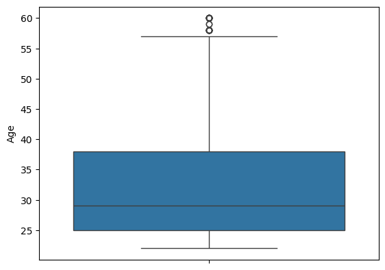

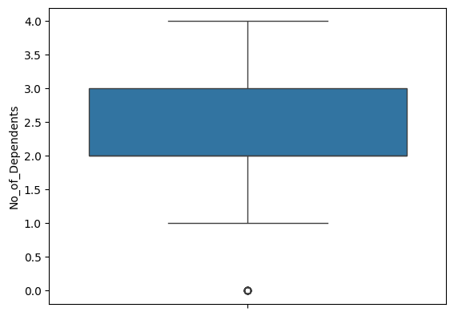

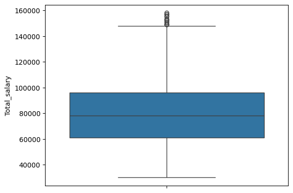

```python
for c in ["Age", "No_of_Dependents", "Total_salary"]:
    sns.boxplot(y=df[c])
    ply.show()
```

Age - The outliers in age are not unusual as there are many older people especially those who are upper class, who invest in vehicles especially the premium level as a hobby.

Dependencies - The outlier in dependencies is not something unusual as many single people can drive cars to make travel easy especially if they live far.

Total salary - These outliers are normal as there are customers like CEOs who have a higher end salary at that range and would most likely invest in a premium vehicle.

## Univariate Analysis

### Numerical

```python
import numpy as np
```

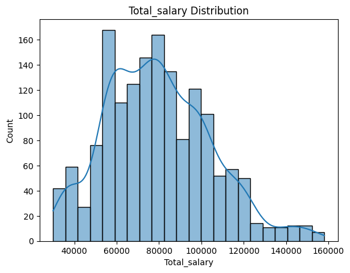

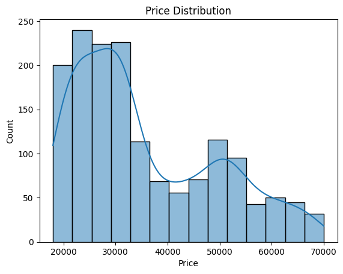

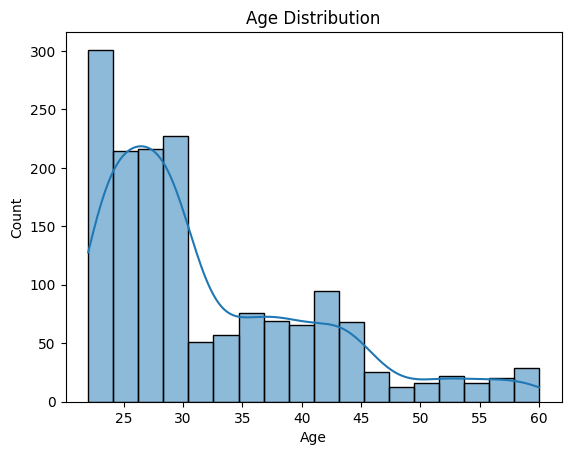

```python
for cat_var in ["Total_salary", "Price", "Age"]:
    ply.Figure()
    sns.histplot(x=cat_var, data=df, kde=True)
    ply.title(f'{cat_var} Distribution')
    ply.show()
```

Why pick total salary? - It reflects the real affordability for the customers

Why use price? - It displays spending behaviour and market demand pattern

Why use age? - It shows the target customer segments and market demographics

#### Key Insights

Total salary - Postively skewed distribution, where majority of the customers earn up to 60000-10000 USD. It peaks at 70000-80000 GBP displaying that most buyers are middle to upper middle class. Higher income (>130000 GBP) are the outliers, showing that the market for high income customers is low. The business should largely focus on the lower-middle customer base more with vehicles that are affordable but bring a lot of value. They can treat the higher-end customers as a niche market providing premium vehicles like luxury cars.

Price - It has a bimodal shape, suggesting two popular price segments. First peak is in the range of 20000-35000 GBP which are the budget prices, and the second peak is in 45000-55000 GBP which are the more premium prices. However first peak is higher showing that most people tend to buy or can only afford the budget prices. The dominance for budget prices indicate that customers demand budget vehicles, but there should be options for premium vehicles too.

### Categorical

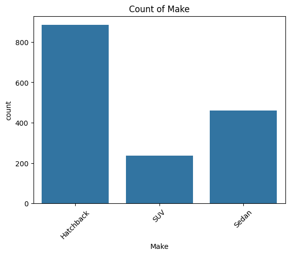

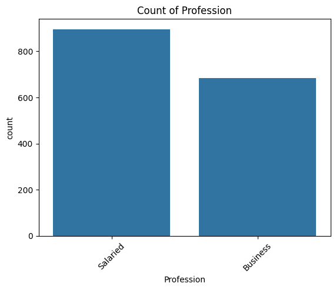

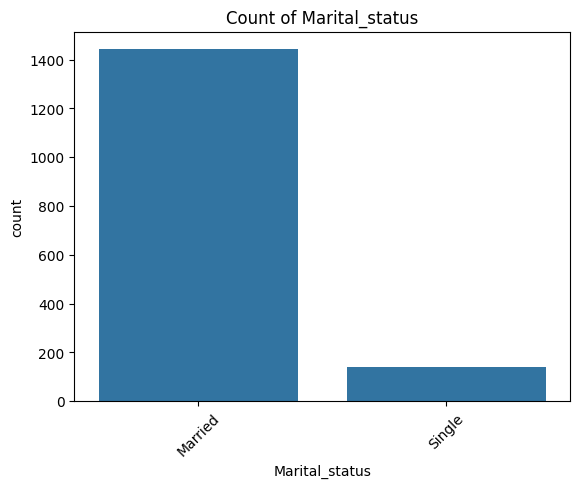

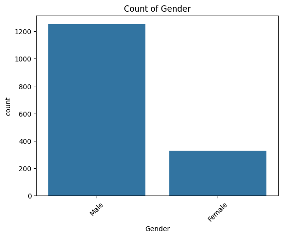

```python
for cat_var in ["Make", "Profession","Marital_status", "Gender"]:
    ply.figure()
    sns.countplot(x=cat_var, data=df,)
    ply.title(f'Count of {cat_var}')
    ply.xticks(rotation = 45)
    ply.show()
```

Why use make? - It shows customer preferences and the most popular vehicle types

Why use profession? - It shows customer economic profile like income and stability.

Why use marital status? - It shows household transportational needs, as families often commute together.

Why use gender? - It can show potential behavioural differences.

#### Key Insights

Make - Hatchback has the highest frequency as they are lower priced. SUV are more premium priced, and has the lowest frequency and since the market is dominated by middle market salaries, it makes sense for hatchbacks to be lower priced. Promoting the budget vehicles and marketing the premium vehicles as niche products can help the business.

Profession - Salaried customers are a common demographic than business owners. This shows that the majority of the customers have a stable monthly income where it is easier for them to apply for vehicle loans and represent a lower financial risk for car dealers. Dealers may want to focus more on salaried customers by providing finance schemes, instalment based payment plans, and partnerships with financial institutions.

Marital Status - Vast majority of the customers are married. This shows that since most of the customers have household responsibilities they will tend to invest in a vehicle to commute with their families. Married customers also tend to be more financially stable. Dealers should promote family friendly vehicle features like safety, how many passengers the vehicle can support, and comfort.

Gender - Male customers dominate the market. This could be due to cultural or behavioural differences in vehicle purchasing, along with the different lifestyles between men and women. The dealership may want to consider expand marketing to females through strategies and features that are appealing to female customers.

## Bivariate Analysis

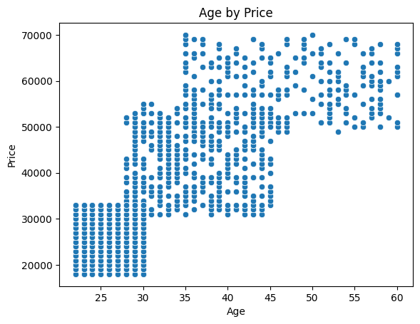

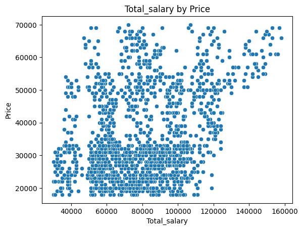

```python
for cat_var in ["Age", "Total_salary"]:
    ply.figure()
    sns.scatterplot(x=cat_var, y=df["Price"], data=df)
    ply.title(f"{cat_var} by Price")
    ply.show()
```

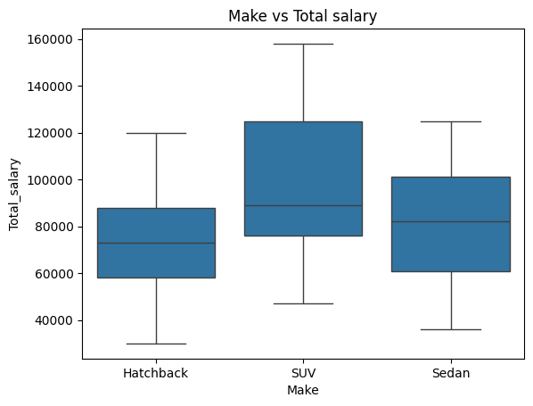

```python
ply.figure()
sns.boxplot(x=df["Make"], y=df["Total_salary"], data=df)
ply.title("Make vs Total salary")
ply.show()
```

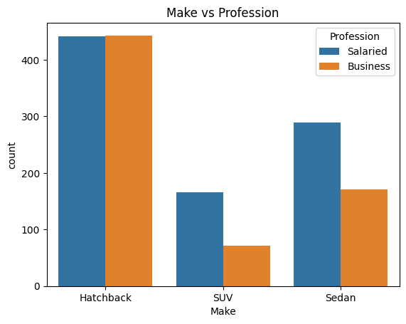

```python
ply.figure()
sns.countplot(x="Make", hue="Profession", data=df)
ply.title("Make vs Profession")
ply.show()
```

Why use age vs price? - To analyse how much age determines spending behaviour

Why use total salary vs price? - To see how much financially stable customers tend to spend on vehicles

Why use make vs total salary? - To see how income level affects customer preference for different vehicle types

Why use make vs profession? - To see how occupation affects prefence for vehicle types.

#### Key Insights

Age vs Price - There is a positive correlation between age and price, showing that younger people in the 20-30 range tend to spend less on vehicles compared to the older customers, especially in the 50-60 age range who spend up to £70000 on vehicles (premium price). This shows that younger people who are early in their careers will spend less as they most likely will earn less compared to older people who have senior level salary, therefore higher income stability. Dealers should market the higher end vehicles to older customers while promoting budget vehicles to younger.

Total salary vs price - There is a positive correlation between these two variables but it is very spread out. Customers from lower income households tend to spend less compared to higher income households. However there is a lot of overlap in spending between lower class and middle/upper middle classes in spending. This could be due to personal preferences, e.g. middle income family paying less for vehicle to save up for house. Because of overlaps, the dealers can promote a wide range of vehicles especially lower and mid-tier to the customers with flexible finance schemes.

Make vs total salary - Hatchback customers typically have the lowest income, sedan customers have a moderate income level, and SUV customers have the highest median income. This shows that lower to middle income families will typically invest in budget vehicles. Dealers should promote hatchbacks as affordable vehicles, with SUVs in the premium tier, and sedans as mid-tier.